# Chronodel Data Analysis

Nicolas Jumel

2026-04-28

**Assessment of Attention in Older Patients Without Chronic Cognitive Impairment in Stable or Unstable Clinical Conditions: A Prospective Descriptive Study**

# 1 Project accessibility

The project is available on GitHub at this link: https://github.com/nicolasjumel/Stat-Chronodel-Rstudio-VSC-Nicolas-Jumel

# 2 The Delirium

## 2.1 General context

**Delirium** is an acute clinical syndrome (ACS) that typically develops in **older adults**. It is characterized by **disturbances** in attention, awareness, and cognition, with a **reduced ability** to focus, sustain, or shift attention. It develops over a short period of time and tends to fluctuate throughout the day. The clinical presentation may vary, often including **psychomotor** and **behavioral** disturbances such as hyperactivity or hypoactivity, as well as alterations in sleep duration and architecture.(1)

The clinical features are defined by the **DSM-5** as follows: a disturbance in attention (Criterion A); a rapid onset of symptoms (Criterion B); symptoms associated with an additional cognitive disturbance (Criterion C). These symptoms must not be better explained by a pre-existing neurocognitive disorder (NCD) or by a severely reduced level of arousal such as coma (Criterion D). There must also be evidence from the medical history, physical examination, or additional investigations supporting a direct medical cause, substance intoxication, medication use, or withdrawal (Criterion E).(2)

## 2.2 Chronodel presentation

The aim of this study is to analyze data from the **Chronodel test**, which assesses the ability to perform a task within **30 seconds—specifically**, counting from 0 to 30 in the correct order, without repetition and without skipping any numbers. The dataset includes a sample of participants (**n = 43**).

The study was **initially** designed to assess the diagnostic performance of the *Chronodel test*, including sensitivity, specificity, positive predictive value (PPV), and negative predictive value (NPV), and to compare its performance with two other tests assessing similar cognitive functions: *Day Of The Week Backward* (*DOTWB*) and *Month Of The Year Backward* (*MOTYB*). (3)

As the study is still ongoing, a **preliminary analysis** of the available data was conducted to **explore** the distribution of results and the level of agreement between the three tests.

## 2.3 Methodological Adjustment: Change in Primary Objective

However, due to a **low variability** in the results — with most participants scoring 1 (indicating success) — the initially planned diagnostic performance analyses were not appropriate.

Therefore, the analysis plan was revised to focus on:

- **the percentage of success** for each test (*DOTWB*, *MOTYB*, *Chronodel*)
- **the concordance** between tests
- **the distribution** of results to assess variability and potential ceiling effects

A small number of missing values were observed. As these were limited and not overlapping across variables, analyses were conducted using available data.

## 2.4 Role of Rstudio

R was used for:

- statistical analysis (Cohen’s kappa)
- graphical representations
- final interpretation of results

# 3 Data organization

**The file** “Stat_Chronodel_Rstudio_test.csv” contains the cleaned dataset with the following variables:

- *jour_reussite* (DOTWB): binary variable indicating success (1) or failure (0) on the Day Of The Week Backward test
- *mois_reussi* (MOTYB): binary variable indicating success (1) or failure (0) on the Month Of The Year Backward test
- *chrono_reussi* : binary variable indicating success (1) or failure (0) on the Chronodel test

# 4 Script organization

## 4.1 Cohen’s kappa

- **aim**: assess the level of agreement between the three tests using Cohen’s kappa coefficient.
- **Input**: cleaned dataset stored in the `Data` folder.
- **output**: Cohen’s kappa coefficients and p-values for each pairwise comparison between the three tests.

## 4.2 cross table

- **aim**: perform a cross-tabulation of results between *DOTWB* and *MOTYB* to assess concordance and discordance rates.
- **Input**: cleaned dataset stored in the `Data` folder.
- **output**: a cross-tabulation table showing the counts of success and failure for *DOTWB* and *MOTYB*, along with calculated concordance and discordance rates saved as (cross_tab_dotwb_motyb.csv) in the `Results` folder.

## 4.3 success rate

- **aim**: to calculate the percentage of success for each test and to visualize these rates using a bar plot.
- **Input**: cleaned dataset stored in the `Data` folder.
- **output**: a bar plot showing the success rates for *DOTWB*, *MOTYB*, and *Chronodel* called “Success rate for the three tests” and saved as (Success_rate_Rstudio.png) in the `Results` folder.

## 4.4 distribution

- **aim**: to visualize the distribution of results for each test to assess variability and potential ceiling effects.
- **Input**: cleaned dataset stored in the `Data` folder.
- **output**: three bar plots showing the distribution of results for *DOTWB*, *MOTYB*, and *Chronodel* called “Distribution DOTWB”, “Distribution MOTYB”, and “Distribution Chronodel” respectively, and saved as (Distribution_Rstudio.png) in the `Results` folder.

# 5 code

## 5.1 Data inclusion

Data cleaning was carried out prior to analysis using Visual Studio Code. The cleaned dataset was then imported into RStudio for statistical analysis from the file “Stat_Chronodel_Rstudio_test.csv”.

```r
# Read the cleaned dataset
Data <- read.csv("Data/Stat_Chronodel_Rstudio_test.csv")
```

## 5.2 Total subjects

**Cohen’s kappa analyses** were conducted using pairwise complete-case datasets for each comparison. **As a result**, the effective sample size **varied** depending on the availability of **both variables** involved in each pair.

```r
# Calculate the number of complete cases for each pairwise comparison
sum(complete.cases(Data[, c("jour_reussite", "mois_reussi")]))
```

```
## [1] 36
```

```r
sum(complete.cases(Data[, c("jour_reussite", "chrono_reussi")]))
```

```
## [1] 37
```

```r
sum(complete.cases(Data[, c("mois_reussi", "chrono_reussi")]))
```

```
## [1] 39
```

## 5.3 Subjects

- *DOTWB* vs *MOTYB* → n = 36
- *DOTWB* vs *Chronodel* → n = 37
- *MOTYB* vs *Chronodel* → n = 39

# 6 Kappa test

```r
# library(irr) for Cohen's kappa analysis for each pairwise comparison
library(irr)
kappa2(Data[, c("jour_reussite", "mois_reussi")])
```

```
##  Cohen's Kappa for 2 Raters (Weights: unweighted)
##
##  Subjects = 36
##    Raters = 2
##     Kappa = 0.0859
##
##         z = 1.27
##   p-value = 0.204
```

```r
kappa2(Data[, c("jour_reussite", "chrono_reussi")])
```

```
##  Cohen's Kappa for 2 Raters (Weights: unweighted)
##
##  Subjects = 37
##    Raters = 2
##     Kappa = 0
##
##         z = 0
##   p-value = 1
```

```r
kappa2(Data[, c("mois_reussi", "chrono_reussi")])
```

```
##  Cohen's Kappa for 2 Raters (Weights: unweighted)
##
##  Subjects = 39
##    Raters = 2
##     Kappa = 0
##
##         z = 0
##   p-value = 1
```

## 6.1 Kappa test results

- *DOTWB* vs *MOTYB* : κ = 0.086 (p = 0.204)
- *DOTWB* vs *Chronodel* : κ = 0 (p = 1)
- *MOTYB* vs *Chronodel* : κ = 0 (p = 1)

The **Cohen’s kappa coefficients** indicated a **very low level** of agreement across the three outcome measures. Agreement between *DOTWB* and *MOTYB* was weak (**κ = 0.086**, **p = 0.204**), whereas no agreement beyond chance was observed between *DOTWB* and *Chronodel* (**κ = 0**, **p = 1**), as well as between *MOTYB* and *Chronodel* (**κ = 0**, **p = 1**).

**Cohen’s kappa** was used as the **primary measure of agreement**, despite known limitations in the presence of highly unbalanced outcome distributions including the so-called paradox of Cohen’s kappa.

Alternative agreement coefficients less sensitive to prevalence (e.g., **Gwet’s AC1**) have been proposed in the literature, but were not implemented in the present analysis due to **software constraints** and **the exploratory nature** of the study.(5)

The **very low kappa values** should be interpreted in light of the **highly unbalanced** outcome distributions. This lack of variability **limits** the ability of agreement statistics to detect concordance beyond chance. These distributional characteristics are further explored in the descriptive analyses.

# 7 Cross table

A cross-tabulation was performed to assess agreement between *DOTWB* and *MOTYB*.(see Table 7.1)

Table 7.1: cross_tab_dotwb_motyb.csv

|  | 0 | 1 |
| --- | --- | --- |
| 0 | 1 | 0 |
| 1 | 13 | 22 |

```r
write.csv(as.data.frame(cross_tab),
          "Results/cross_tab_dotwb_motyb.csv",
          row.names = FALSE)
```

## 7.1 *DOTWB* vs *MOTYB* Concordance

- 1 subject failed both *DOTWB* and *MOTYB*
- 0 subjects failed *DOTWB* but succeeded *MOTYB*
- 13 subjects succeeded *DOTWB* but failed *MOTYB*
- 22 subjects succeeded in both tests

This corresponds to a **concordance rate** of 63.9% (23/36) and a **discordance rate** of 36.1% (13/36). These results are consistent with the low level of agreement observed using Cohen’s kappa

# 8 success rate

The success rates of the three tests were analysed to assess their coherence and potential ceiling effects (see Figure 8.1).

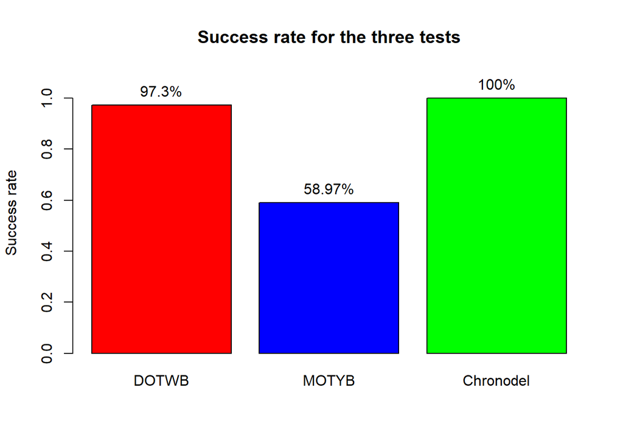

Figure 8.1: Success rates for the three tests

```r
# name each data column for clarity

taux_jour <- mean(Data$jour_reussite, na.rm = TRUE)
taux_mois <- mean(Data$mois_reussi, na.rm = TRUE)
taux_chrono <- mean(Data$chrono_reussi, na.rm = TRUE)

# create a vector of success rates for the three tests

taux <- c(taux_jour, taux_mois, taux_chrono)

# create a bar plot of success rates

bp <- barplot(taux,
        names.arg = c("DOTWB", "MOTYB", "Chronodel"),
        ylim = c(0,1.1),
        ylab = "Success rate",
        main = "Success rate for the three tests",
        col = c("red", "blue", "green"))
# add text labels with success rates on top of the bars
text(bp, taux,
     labels=paste0(round(taux*100, 2), "%"),
     pos=3)
```

Overall, success rates were **97.3%** for the *DOTWB* test, **58.97%** for the *MOTYB* test, and **100%** for the *Chronodel test*. A ceiling effect is suggested for the *DOTWB* and *Chronodel test* due to their high success rates, while the *MOTYB* test shows a **more balanced distribution** without evidence of a ceiling effect.

# 9 Distribution

The final figure presents the distribution of results across the three tests, in order to assess **variability** and potential **ceiling effects**.(see Figure 9.1).

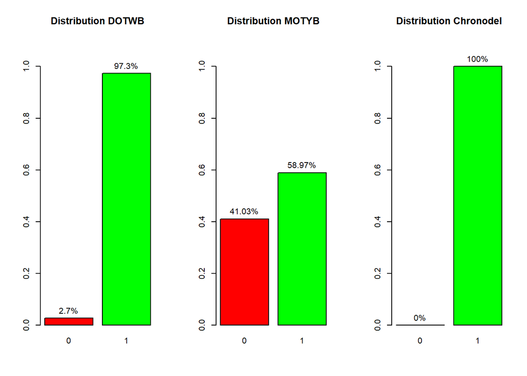

Figure 9.1: Distribution results for the three tests

```r
# function to plot the distribution of binary outcomes for each test

plot_binary <- function(x, title){

# create a table of counts for the binary variable, ensuring that both 0 and 1 are included as levels

  tab <- table(factor(x, levels=c(0,1)))
  tab <- prop.table(tab)

# create a bar plot of the distribution of outcomes

  bp <- barplot(tab,
                main=title,
                ylim=c(0,1.1),
                col=c("red","green"),
                names.arg=c("0","1"))

# add text labels with percentages on top of the bars

  text(bp, tab,
       labels=paste0(round(tab*100,2),"%"),
       pos=3)
}

# set up the plotting area to display three plots side by side

par(mfrow=c(1,3))

plot_binary(Data$jour_reussite, "Distribution DOTWB")
plot_binary(Data$mois_reussi, "Distribution MOTYB")
plot_binary(Data$chrono_reussi, "Distribution Chronodel")
```

```r
par(mfrow=c(1,1))
```

The distribution of the *DOTWB* test results is highly skewed, with a majority of successful outcomes, **suggesting** a ceiling effect.

The *MOTYB* test shows a more balanced distribution, with **41.03%** “no” and **58.97%** “yes”, which **does not suggest a ceiling effect**.

For the *Chronodel test*, all participants achieved a successful outcome, **suggesting** a ceiling effect.

Ceiling effects may **limit** the **interpretability** of test scores when a task is too easy, leading to an accumulation of maximal scores and **reduced discriminative capacity** (4)

# 10 Main results

- The *Chronodel* test strongly suggests a ceiling effect.
- The *DOTWB* test suggests a ceiling effect.
- The *MOTYB* test shows a more balanced distribution.

**This interpretation is descriptive and based on outcome distributions rather than on a formal statistical test of ceiling effects. Missing values were limited and did not overlap across variables; therefore, complete-case analyses were performed.**

# 11 References

1. Andorra, Boris, Alexandre Boussuge, Thomas Gilbert, et al. ‘Le Repérage et Le Diagnostic de l’état Confusionnel Aigu Chez Les Personnes Âgées : Quels Outils Rapides ?’ Gériatrie et Psychologie Neuropsychiatrie Du Vieillissement 20, no. 1 (2022): 17–27. https://doi.org/10.1684/pnv.2022.1022.
2. Garnier-Crussard, Antoine, Clémence Grangé, Jean-Michel Dorey, and Guillaume Chapelet. ‘Diagnostic et Prise En Soins Du Syndrome Confusionnel Aigu Chez La Personne Âgée’. La Revue de Médecine Interne 46, no. 5 (2025): 265–75. https://doi.org/10.1016/j.revmed.2024.11.005.
3. Ramírez Echeverría, María de Lourdes, and Caroline Schoo. ‘Delirium’. In StatPearls. StatPearls Publishing, 2026. http://www.ncbi.nlm.nih.gov/books/NBK470399/.
4. Rasmussen, L. S., K. Larsen, P. Houx, et al. ‘The Assessment of Postoperative Cognitive Function’. Acta Anaesthesiologica Scandinavica 45, no. 3 (2001): 275–89. https://doi.org/10.1034/j.1399-6576.2001.045003275.x.
5. Zec, Slavica, Nicola Soriani, Rosanna Comoretto, and Ileana Baldi. ‘High Agreement and High Prevalence: The Paradox of Cohen’s Kappa’. The Open Nursing Journal 11 (October 2017): 211–18. https://doi.org/10.2174/1874434601711010211.

**ChatGPT (OpenAI) was used for language editing and clarification. The author remains fully responsible for the content.**